# The OSA miRs Database

# 1 Scientific Context

## 1.1 Introduction

The OSA miRs database is a manually curated database that aims to compile experiment-supported findings regarding differentially expressed microRNAs (miRNAs) in Obstructive Sleep Apnea (OSA) (Figure 1). Obstructive Sleep Apnea (OSA) is one of the most prevalent sleep disorders in the world. It is characterized by repetitive episodes of complete (apnea) or partial (hypopnea) obstruction of the upper airways during sleep, resulting in intermittent hypoxia and sleep fragmentation<sup>1,2</sup>. The diagnosis and treatment of OSA is still challenging<sup>3–5</sup>. OSA diagnosis involves a sleep study (type I to type III) that is expensive, labor intensive, and time consuming<sup>1,2,4</sup>. Although Continuous Positive Airway Pressure (CPAP) is the first-line and most effective treatment, patient adherence is often low and and doubts persist regarding its impact on comorbid conditionsd<sup>2,4</sup>. Untreated OSA has been linked to multiple health conditions<sup>6-16</sup>. The clinical community emphasizes the necessity for biomarkers to aid in the diagnosis, stratification, and monitoring of treatment responses; however, to date, no biomarkers have been validated<sup>17,18</sup>.  
MicroRNAs are small single-stranded noncoding RNAs of approximately<sup>21–25</sup> nucleotides that have emerged as potential biomarkers in the context of several diseases19. MicroRNAs are powerful regulators of post-transcriptionally gene expression. Specifically, these noncoding RNAs interact with messenger RNAs (mRNAs) through complementary base pairing, leading to translational repression or mRNA degradation<sup>20–22</sup>. MiRNAs are thus important regulators of diverse cellular and physiological processes<sup>23–25</sup>. In this context, numerous studies have sought to identify microRNA signatures specific to OSA (reviewed<sup>26,27</sup>). Identifying dysregulated miRNAs and their associated gene targets may offer crucial insights into the underlying mechanisms of OSA and its pleiotropic effects, paving the way for improved clinical approaches to managing this condition.

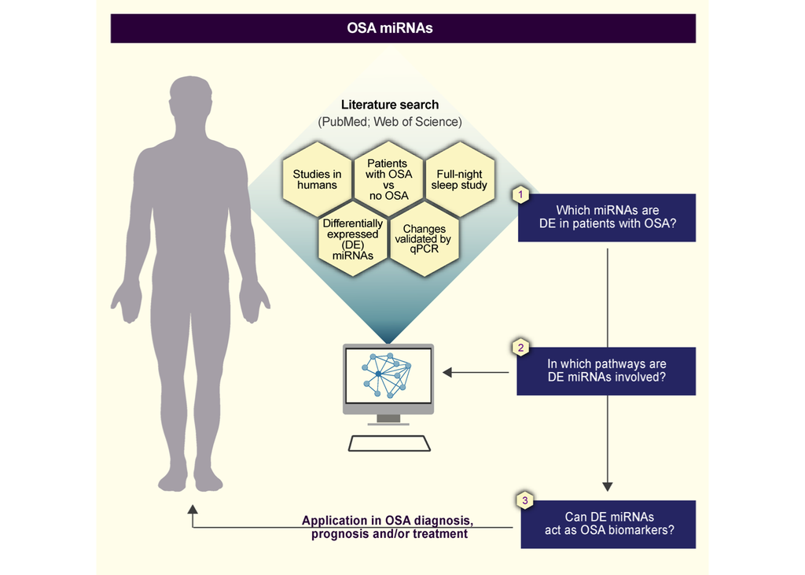

**Figure 1: Graphical abstract**. Two databases were used to retrieve human observational studies comparing patients with and without OSA, diagnosed by a full-night sleep study that reported differentially expressed (DE) miRNAs in patients with OSA and validated by reverse transcription quantitative real-time PCR. From these studies, we retrieved DE miRNAs in patients with OSA relative to control subjects, which allowed the exploration of implicated pathways and identification of potential biomarkers of OSA with applications in OSA diagnosis, prognosis, and treatment. Figure created with the Adobe Illustrator by Laetitia Gaspar.

**References**

1. [DOI: 10.1007/978-1-4939-6578-6_27](https://doi.org/10.1007/978-1-4939-6578-6_27)
2. [DOI: 10.1001/jama.2020.3514](https://doi.org/10.1001/jama.2020.3514)
3. [DOI: 10.1097/MCP.0000000000000724](https://doi.org/10.1097/MCP.0000000000000724)
4. [DOI: 10.1183/13993003.02616-2017](https://doi.org/10.1183/13993003.02616-2017)
5. [DOI: 10.1016/j.chest.2019.09.002](https://pubmed.ncbi.nlm.nih.gov/31539538/)
6. [DOI: 10.1136/BMJOPEN-2020-041179](https://doi.org/10.1136/BMJOPEN-2020-041179)
7. [DOI: 10.1183/23120541.00338-2021](https://openres.ersjournals.com/content/7/3/00338-2021)
8. [DOI: 10.1161/JAHA.120.021318](https://doi.org/10.1161/JAHA.120.021318)
9. [DOI: 10.1186/s13643-021-01759-6](https://doi.org/10.1186/s13643-021-01759-6)
10. [DOI: 10.1164/ajrccm.165.5.2103001](https://doi.org/10.1164/ajrccm.165.5.2103001)
11. [DOI: 10.1378/chest.13-2403](https://pubmed.ncbi.nlm.nih.gov/24831859/)
12. [DOI: 10.1016/J.BIOPHA.2021.112425](https://doi.org/10.1016/J.BIOPHA.2021.112425)
13. [DOI: 10.1016/J.SLEEP.2021.05.031](https://doi.org/10.1016/J.SLEEP.2021.05.031)
14. [DOI: 10.1093/SLEEP/ZSAA204](https://doi.org/10.1093/SLEEP/ZSAA204)
15. [DOI: 10.1038/s41598-020-80759-3](https://doi.org/10.1038/s41598-020-80759-3)
16. [DOI: 10.1016/j.phrs.2020.105369](https://pubmed.ncbi.nlm.nih.gov/33352231/)
17. [DOI: 10.5664/JCSM.6506](https://doi.org/10.5664/JCSM.6506)
18. [DOI: 10.1016/J.SMRV.2022.101659](https://doi.org/10.1016/J.SMRV.2022.101659)
19. [DOI: 10.3390/CELLS9020276](https://doi.org/10.3390/CELLS9020276)
20. [DOI: 10.1016/j.cell.2009.01.002](https://doi.org/10.1016/j.cell.2009.01.002)
21. [DOI: 10.1038/nrg2843](https://doi.org/10.1038/nrg2843)
22. DOI: 10.1016/S0092-8674(04)00045-5
23. [DOI: 10.3389/fcell.2020.00409](https://doi.org/10.3389/fcell.2020.00409)
24. [DOI: 10.1093/bib/bbx130](https://doi.org/10.1093/bib/bbx130)
25. [DOI: 10.1093/cvr/cvn156](https://doi.org/10.1093/cvr/cvn156)
26. [DOI: 10.3390/BIOLOGY12010066](https://doi.org/10.3390/BIOLOGY12010066)
27. [DOI: 10.1016/J.SMRV.2021.101458](https://doi.org/10.1016/J.SMRV.2021.101458)

## 1.2 Key Points

We proposed the compilation of the available literature concerning microRNAs dysregulated in OSA to create a structured and comprehensive OSA miRNA database: the OSA miRs database. Each entry in the OSA miR database provides information on 14 items:

1. Name of the assessed miRNAs.
2. Accession number
3. Observed change (up-or downregulated) or no change.
4. Biological samples in which miRNA expression was evaluated.
5. Collection time for biological samples.
6. Cohort size.
7. Study groups.
8. Sex of the study participants.
9. Age of the study participants.
10. Body mass index (BMI) of study participants.
11. Apnea-Hypopnea Index (AHI) of the study participants.
12. Comorbidities of the study participants.
13. Correlations between the expression of the studied miRNAs and clinical measurements.
14. Study reference.

The OSA miRs database is intended to be a valuable resource to accelerate future investigations into the molecular mechanisms of OSA and the discovery of clinically applicable biomarkers.

# 2 DataBase

| Entry number | miRNA | Acession number | Change | Biological sample | Collection time | Cohort, size [n (M/F)] | Groups, size [n (M/F)] | Age (years ± SD) | BMI (kg/m2 ± SD) | AHI (events/hour of sleep) | Comorbidities | Correlations | Evaluated after treatment | Ref |
| --- | --- | --- | --- | --- | --- | --- | --- | --- | --- | --- | --- | --- | --- | --- |
| 24 | hsa-let-7a-1-5p | MIMAT0000062 | NC | PBMCs | Morning | Adults, n = 65 (46/19) | With OSA, n = 45 (34/11) | OSA (48.5 ± NR) | OSA (26.4 ± 3.4) | OSA (54.8 ± 19.2) | HT. DM. Heart disease. COPD. Depression | NR | N | 5 |
| 24 | hsa-let-7a-1-5p | MIMAT0000062 |  | PBMCs | Morning | Adults, n = 65 (46/19) | Without OSA (Primary-snoring), n = 20 (12/8) | Primary-snoring (44.6 ± 12.6) | Primary-snoring (25.1 ± 3.6) | Primary-snoring (2.7 ± 1.8) | HT. DM. Heart disease. COPD. CDK. Depression | NR |  | 5 |
| 24 | hsa-let-7a-1-5p | MIMAT0000062 | NE | PBMCs | Morning | Adults, n = 65 (46/19) | On CPAP treatment, n = 13 (11/2) | OSA-CPAP (50.6 ± 7.5) | OSA-CPAP (27.3 ± 2.9) | OSA-CPAP (62.5 ± 23.3) | HT. DM. Heart disease. COPD. Depression | NR |  | 5 |
| 10 | hsa-let-7b-5p | MIMAT0000063 | D | UA skeletal muscle | NR | Adults, n = 20 (12/8) | With OSA, n = 10 (7/3) | OSA (35.21± 1.9*) | OSA (30.1 ± 1.1*) | OSA (72.4 ± 5.1*) | NR (TG. Excessive weight/ Obesity) | NR | N | 3 |
| 10 | hsa-let-7b-5p | MIMAT0000063 |  | UA skeletal muscle | NR | Adults, n = 20 (12/8) | Without OSA (Chronic tonsillitis), n = 10 (5/5) | Chronic tonsillitis (36.8 ± 2.0*) | Chronic tonsillitis (27.6 ± 1.3*) | Chronic tonsillitis (2.0 ± 1.2*) | NR (Excessive weight) | NR |  | 3 |
| 41 | hsa-let-7d-5p | MIMAT0000065 | D | Serum | 8h | Adults, n = 45 (36/9) | With OSA, n = 15 (13/2) | OSA (43 ± 2.5*) | OSA (25.6 ± 0.4*) | OSA (47.4 ± 4.9*) | NR | NR | N | 8 |
| 41 | hsa-let-7d-5p | MIMAT0000065 |  | Serum | 8h | Adults, n = 45 (36/9) | Without OSA, n = 15 (11/4) | Non-OSA (43.4 ± 2.1*) | Non-OSA (24.6 ± 0.5*) | Non-OSA (4.5 ± 0.6*) | NR | NR |  | 8 |
| 41 | hsa-let-7d-5p | MIMAT0000065 | U | Serum | 8h | Adults, n = 45 (36/9) | With OSA + HT, n =15 (12/3) | OSA + HT (43.6 ± 2.3*) | OSA + HT (26.2 ± 0.6*) | OSA + HT (43.5 ± 5.2*) | NR | NR | N | 8 |
| 11 | hsa-let-7g-5p | MIMAT0000414 | D | UA skeletal muscle | NR | Adults, n = 20 (12/8) | With OSA, n = 10 (7/3) | OSA (35.21± 1.9*) | OSA (30.1 ± 1.1*) | OSA (72.4 ± 5.1*) | NR (TG. Excessive weight/ Obesity) | NR | N | 3 |
| 11 | hsa-let-7g-5p | MIMAT0000414 |  | UA skeletal muscle | NR | Adults, n = 20 (12/8) | Without OSA (Chronic tonsillitis), n = 10 (5/5) | Chronic tonsillitis (36.8 ± 2.0*) | Chronic tonsillitis (27.6 ± 1.3*) | Chronic tonsillitis (2.0 ± 1.2*) | NR (Excessive weight) | NR |  | 3 |

[output cut: 161 more lines]

*Footnote:* AHI: Apnea-Hypopnea Index; BMI: Body mass index; CDK: Chronic Kidney Disease; COPD: Chronic obstructive pulmonary disease; D: Down-regulated; DM: Diabetes mellitus; EVs: Extracellular Vesicles; FEV1: Forced expiratory volume in the first second; HC: COPD with chronic Hypoxia- ODI < 5; diurnal PaO2 < 60 mmHg; HCHI: Intermittent and Chronic Hypoxia: ODI> 15; diurnal PaO2 < 60 mmHg; HI: Intermittent Hypoxia -ODI > 15; diurnal PaO2 ≥ 60 mmHg; HT: Hypertension; iCIMT: Carotid intima-media thickness; Max: maximum; N: No; NC: No Change; NE: Not evaluated; NR: Not reported; PBMCs: Peripheral blood mononuclear cells; Ref: Reference; SpO2: Peripheral oxygen saturation; SaO2: Arterial Oxygen Saturation; TG: Hypertriglyceridemia; U: Up-regulated; UA: Upper airway; Y: Yes; ?: Not clear; (-) inverse correlation; (+) direct correlation; *: SEM; #: median (interquartile range)

**Sources**

1. [DOI: 10.1166/MEX.2020.1646](https://doi.org/10.1166/MEX.2020.1646)
2. [DOI: 10.18632/ONCOTARGET.26210](https://doi.org/10.18632/ONCOTARGET.26210)
3. [DOI: 10.1177/0300060519858900](https://doi.org/10.1177/0300060519858900)
4. [DOI: 10.1097/MD.0000000000007917](https://doi.org/10.1097/MD.0000000000007917)
5. [DOI: 10.3390/ANTIOX10111854](https://doi.org/10.3390/ANTIOX10111854)
6. [DOI: 10.3390/IJMS21030999](https://doi.org/10.3390/IJMS21030999)
7. [DOI: 10.1097/MD.0000000000009813](https://doi.org/10.1097/MD.0000000000009813)
8. [DOI: 10.1186/S12931-018-0894-9](https://doi.org/10.1186/S12931-018-0894-9)
9. [DOI: 10.36468/PHARMACEUTICAL-SCIENCES.SPL.147](https://doi.org/10.36468/PHARMACEUTICAL-SCIENCES.SPL.147)
10. [DOI: 10.1007/s11325-019-02003-1](https://pubmed.ncbi.nlm.nih.gov/31898194/)

# 3 Methodology

The protocol that guided the development of The OSA miRs database is available in Gaspar & Capitão et al., 2024. The inclusion of future studies and updating of the OSA miR database will be carried out following the same eligibility criteria. Literature search will be updated each year. Studies can also be submitted in this form.

**Do you want to add your study to the OSA miRNA database?**  
Please contact us at sleepapneaid.cnc-at-gmail.com (replace *-at-* with @). We will analyze the study and update the database if the study is eligible.

Subject:

Message:

# 4 Authors

Laetitia S. Gaspar

Ana Capitão

Bárbara Santos

Alexandrina Ferreira Mendes

Cláudia Cavadas

Irina S. Moreira

Ana Rita Álvaro

# 5 Research groups

[Neuroendocrinology and Aging Group](https://cnc.uc.pt/en/research-group/neuroendocrinologia-e-envelhecimento)  
[Data-Driven Molecular Design Group](https://cnc.uc.pt/en/research-group/design-molecular-de-dados)

[figure not shown]

# 6 Funding

[figure not shown]